# Cross Validation

# 1 Cross Validation

Cross validation is an alternative approach to training/testing split. For k-fold cross validation, the dataset is divided into k parts. Each part serves as the test set in each iteration and the rest serve as training set. The out-of-sample performance measures from the k iterations are averaged. Instead of fitting a model on a pre-specified 90% training sample and evaluate the MSPE on the hold-out 10% testing sample, it is more reliable to use cross-validation for out-of-sample performance evaluation. For k-fold cross-validation, the dataset is divided into k parts (equal sample size). Each part serves as the testing sample in and the rest (k-1 together) serves as training sample. This training/testing procedure is iteratively performed k times. The CV score is usually the average of the metric of out-of-sample performance across k iterations.

Note

1. We use the **full** data (or all the data available) for cross validation
2. If you use cross validation to determine tuning parameters such as in LASSO, you should use the training data only (or equivalently all the data available to build the training model).
3. We need to use glm instead of lm to fit the model (if we want to use cv.glm fucntion in boot package)
4. The default measure of performance is the Mean Squared (Prediction) Error (MSPE) for continuous responses in regression such as medv in Boston housing case. If we want to use another measure we need to define a cost function.

## 1.1 Cross validation for linear model

### 1.1.1 10-fold Cross Validation

The `cv.glm` is the cross validation approach in R for glm (more details of arguments are in help doc). By comparing the cross-validation estimate of prediction error, we can tell the full model outperforms the model with only `indus` and `rm` in terms of prediction error.

```r
library(MASS)
data(Boston); #this data is in MASS package
library(boot)
model_full <- glm(medv~., data = Boston)
cv.glm(data = Boston, glmfit = model_full, K = 10)$delta[2]
```

```
## [1] 23.60391
```

```r
model_2 <- glm(medv~indus + rm, data = Boston)
cv.glm(data = Boston, glmfit = model_2, K = 10)$delta[2]
```

```
## [1] 39.57176
```

### 1.1.2 10-fold Cross Validation Using MAE

Here we need to define a MAE cost function. The function takes 2 input vectors, pi = predicted values, r = actual values.

```r
MAE_cost <- function(pi, r){
  return(mean(abs(pi-r)))
}

cv.glm(data = Boston, glmfit = model_full, cost = MAE_cost, K = 10)$delta[2]
```

```
## [1] 3.382529
```

```r
cv.glm(data = Boston, glmfit = model_2, cost = MAE_cost, K = 10)$delta[2]
```

```
## [1] 4.270944
```

### 1.1.3 LOOCV (Leave-one-out Cross Validation)

The same finding is observed by conducting LOOCV.

```r
cv.glm(data = Boston, glmfit = model_full, K = nrow(Boston))$delta[2]
```

```
## [1] 23.72388
```

```r
cv.glm(data = Boston, glmfit = model_2, K = nrow(Boston))$delta[2]
```

```
## [1] 39.94028
```

### 1.1.4 Cross Validation to search optimal tuning parameter in LASSO

Using 10-fold cross-validation to search optimal lambda, assume that you have the full data available to build a training model:

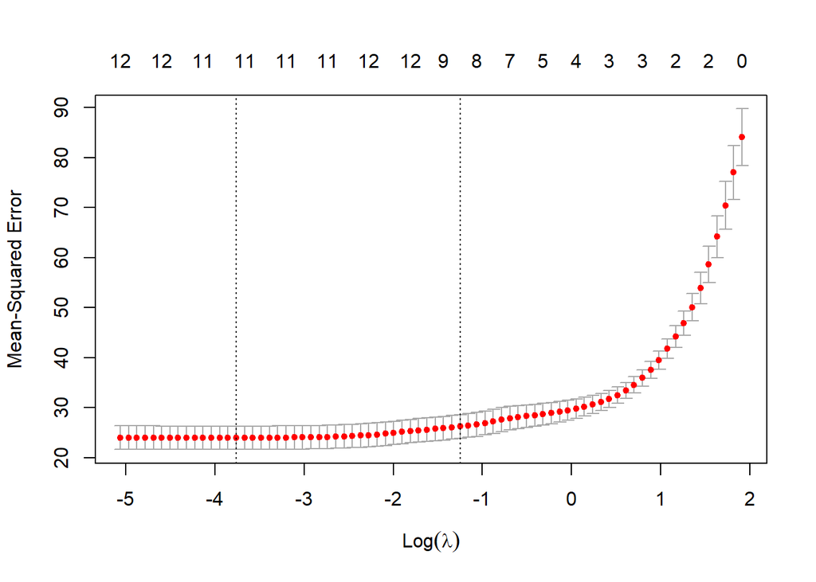

```r
library(glmnet)
lasso_fit  <- glmnet(x = as.matrix(Boston[, -c(which(colnames(Boston)=='medv'))]), y = Boston$medv, alpha = 1)
#use 10-fold cross validation to pick lambda
cv_lasso_fit = cv.glmnet(x = as.matrix(Boston[, -c(which(colnames(Boston)=='medv'))]), y = Boston$medv, alpha = 1, nfolds = 10)
plot(cv_lasso_fit)
```

The best $\lambda$ (or *s*) is given by:

```r
cv_lasso_fit$lambda.min
```

```
## [1] 0.02325053
```

Given a selected *s* you can use *predict()* this way to get prediction:

```r
coef(lasso_fit, s = cv_lasso_fit$lambda.min)
```

```
## 14 x 1 sparse Matrix of class "dgCMatrix"
##                        s1
## (Intercept)  34.741082550
## crim         -0.099983351
## zn            0.042163911
## indus         .
## chas          2.691362170
## nox         -16.484121376
## rm            3.856387746
## age           .
## dis          -1.412063666
## rad           0.260319555
## tax          -0.010144690
## ptratio      -0.932724941
## black         0.009070332
## lstat        -0.522516834
```

```r
pred_IS <- predict(lasso_fit, as.matrix(Boston[, -c(which(colnames(Boston)=='medv'))]), s = cv_lasso_fit$lambda.min)
MAE_cost(pred_IS, Boston$medv)
```

```
## [1] 3.25837
```

go to top